# Lab10

Lauren Gregg, Katie Jiang, Ryan Marizza, Chris He

3/23/2018

# Team Main Questions

What is the relationship between the timeliness of an answer and its score? And what kinds of features affect the good questions and answers most?

# Team Work

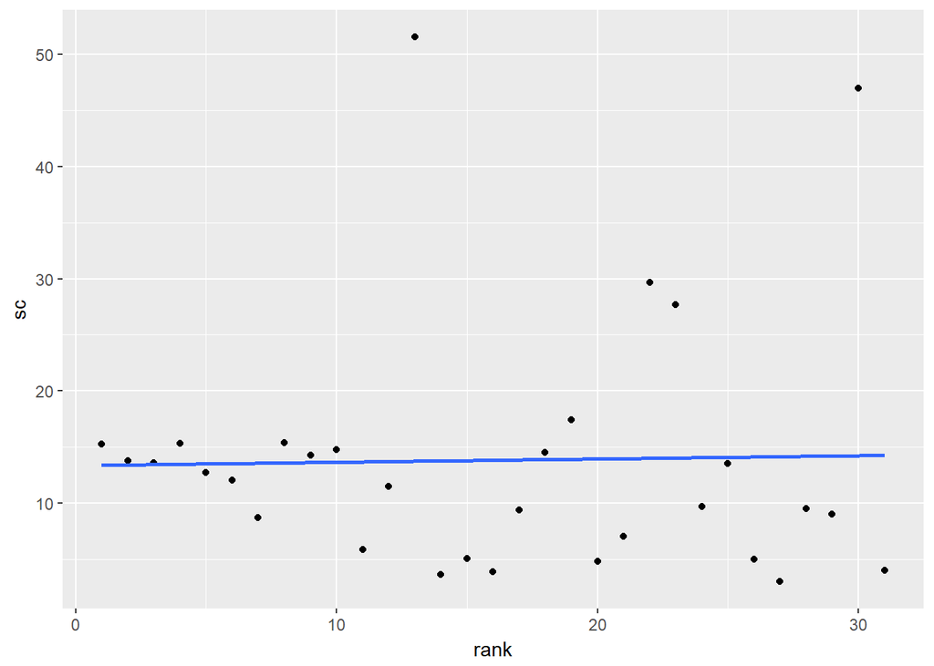

```r
QnA<-left_join(questions,answers,by = c('Id'='ParentId'))

QnA<-QnA%>%mutate(time_to_answer = as.numeric(difftime(CreationDate.y, CreationDate.x,units = "mins")))#this gives the time to answer in seconds

QnA<-QnA%>%filter(CreationDate.x<CreationDate.y)%>%group_by(Id)%>%mutate(rank = row_number(time_to_answer))#here's where answers are ranked by their time to answer

QnA_rank<-QnA%>%group_by(rank)%>%summarise(sc = mean(Score.y))

ggplot(data = QnA_rank)+
  geom_point(aes(x = rank,y = sc))+
  geom_smooth(aes(x = rank,y=sc),method = lm,se=FALSE)
```

```r
#Maybe this isnt the best way to judge timliness (seems more like relative timliness)
```

The plot above shows the relationship (or lack of relationship) between the timliness of a response, and its score. Timliness here is given as the order in which the answer appeared. That is: the chronologically first answer gets a rank of 1, the second 2, and so on. It seems, from this plot, that the rank, in this sense, of the answer has little to no effect on the score.

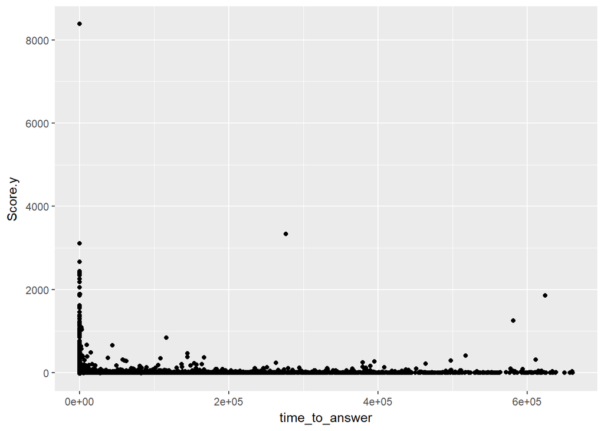

```r
ggplot(data = QnA)+
  geom_point(aes(x = time_to_answer,y = Score.y))
```

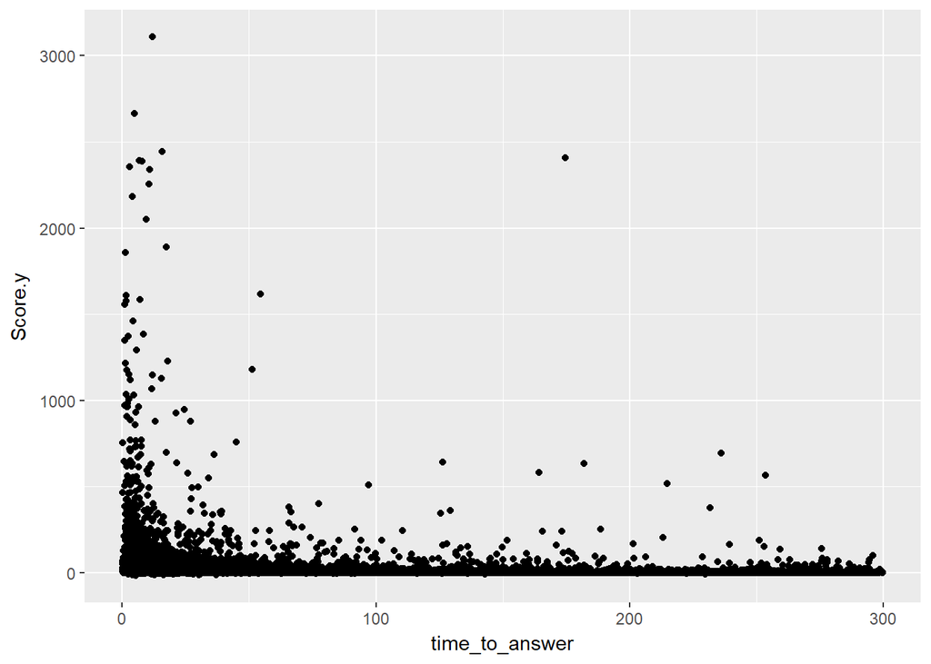

```r
QnA_short_term<-QnA%>%filter(time_to_answer < 60*5,Score.y<4000)

ggplot(data = QnA_short_term)+
  geom_point(aes(x = time_to_answer,y = Score.y))
```

These two plots show the relationship between score and time to answer. These plots show a different relationship between timliness and the score than the first plot. I would guess that this is because in the “ordered” ranking method of timliness, timliness is viewed as timliness compared to other answerers. This means that an answer with rank = 20 may have been submitted only 25 minutes after the question (given that 19 answers were submitted less than 25 minutes after the question). It seems that timliness does indeed have an effect on score, but the important thing is the literal time it took after the question before the answer was posted, and not the chronological rank of the answer’s timliness.

Another significant factor in a question/answer’s score is the amount of words used.

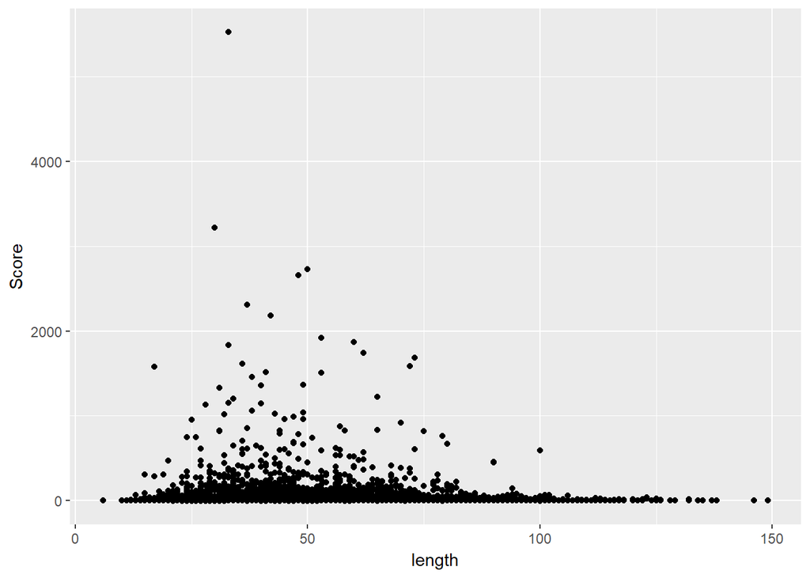

```r
questions<- questions%>%mutate(length = str_length(Title))

ggplot(data = questions)+
  geom_point(aes(x = length,y=Score))
```

```r
answers<- answers%>%mutate(yous = str_count(Body,"you"))%>%mutate(length = str_length(Body))%>%filter(length<5000)


ggplot(data = answers)+
  geom_point(aes(x = length,y=Score))
```

[output not shown]

## Explanation of why these features affect most

It seems from the above plots that literal timliness has a huge effect on score. This is likley because after a certain amount of time, the question is forgotten, answered, or solved by the questioner. Therefore, it makes sense that an answer posted soon after the question would recieve a higher score than one posted later.

# Individual Work

## Lauren

As I have learned in my statistical collaboration course, building a relationship can help with successful collabortaion. I was interested if this translated similarly online. I thought politeness was a key factor in a strong relationship, so I was interested if manners impacted the score of questions. I identified manners as please or thank you.

```r
LGanswers <- answers %>% select(-X7)
LGquestions <- questions %>% select(-X7)


manners = c("thanks", "thx", "Thank you", "Thanks", "please", "Please", "pls", "plz", "Plz")

LGquestions$Manners = str_detect(LGquestions$Body, manners)
```

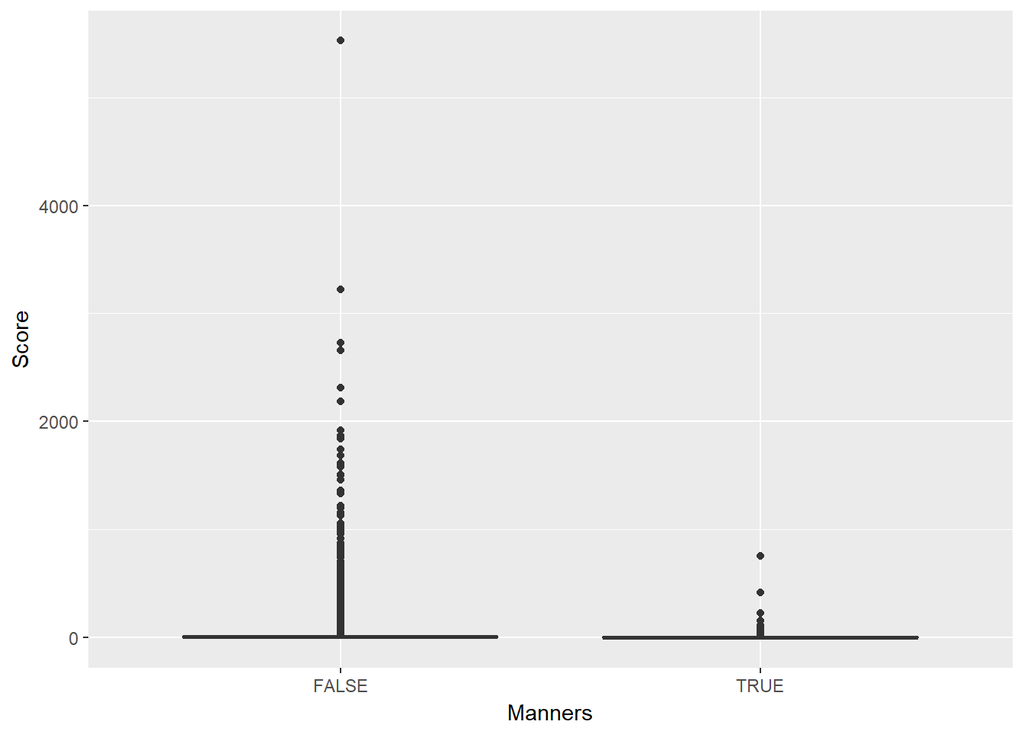

```r
ggplot(LGquestions) +
  geom_boxplot(aes(Manners, Score))
```

As we can see from the above boxplots, saying please or thank you in an online platform is not correlated with a higher score. This does make sense because a question is probably upvoted for its content, not its politeness.

Next, I considered the answer data. I figured, most of these posters are probably wanting to gather as much information as possible. I was interested to see if including a webpage reference in the answer would have a higher number of votes.

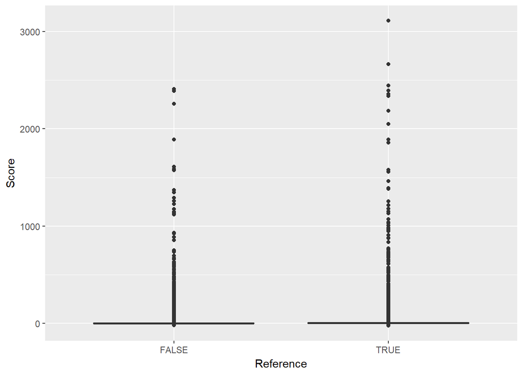

```r
LGanswers$Reference = str_detect(LGanswers$Body, "href")

ggplot(LGanswers) +
  geom_boxplot(aes(Reference, Score))
```

```r
trueData <- LGanswers %>% filter(LGanswers$Reference == TRUE)
falseData <- LGanswers %>% filter(LGanswers$Reference == FALSE)

t.test(trueData$Score, falseData$Score)
```

```
##
##  Welch Two Sample t-test
##
## data:  trueData$Score and falseData$Score
## t = 7.1984, df = 23904, p-value = 6.273e-13
## alternative hypothesis: true difference in means is not equal to 0
## 95 percent confidence interval:
##  4.059756 7.097892
## sample estimates:
## mean of x mean of y
##  15.78395  10.20513
```

When computing a quick t-test, we can see that there is a significant difference between the scores when a reference is used and when a references is not used. This leads me to believe that referencing a link with more information on the topic could result in a higher score.

## Kaite

For the questions and answers, I am interested in the high range score, which words have the high numbers of appearance. I created two features which are all about the highest frequency words showing in high score questions and answers. Because the good quality of answers and questions needs some words that make them popular in readers.

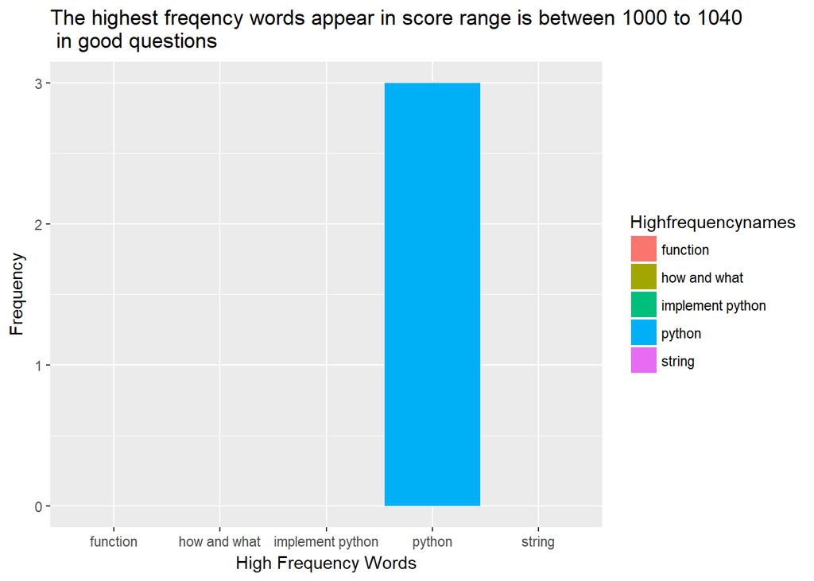

```r
Question<- questions %>% select(OwnerUserId,Score,Title)
Answers<- answers %>% select(OwnerUserId,Score,Body)
newQ<-tibble(id = Question$OwnerUserId, Score = Question$Score, Title = Question$Title)
iduser <- as.integer(newQ$id)
Score1 <- as.integer(newQ$Score)
title1<- as.character(newQ$Title)
newQ1 <- tibble(iduser = iduser,Score1 = Score1, title1 = title1)
nQ <- newQ1 %>% arrange(desc(Score1))
nQ <- nQ %>% filter(Score1 >= 1000 & Score1 <= 1040)
python <- sum(str_count(nQ$title1,"p|Python+"))
Function<- sum(str_count(nQ$title1,"function+"))
HowandWhat <- sum(str_count(nQ$title1,"^H|how|W|what"))
implement<- sum(str_count(nQ$title1,"I|implement(?=p|Python)"))
String<- sum(str_count(nQ$title1,"p|python(?= function|string)"))
plotQ<- tibble(Highfrequencynames = c("python","function","how and what","implement python","string"),frequency = c(python,Function,HowandWhat,implement,String))

ggplot(plotQ)+
  geom_col(mapping = aes(x= Highfrequencynames, y = frequency,fill = Highfrequencynames))+
  labs(x = "High Frequency Words", y = "Frequency",title = "The highest freqency words appear in score range is between 1000 to 1040\n in good questions")
```

In question part, during the high range of scores, we can see the words python appearing lots of times, which means most readers like the python questions and they also have trouble in solving python questions.

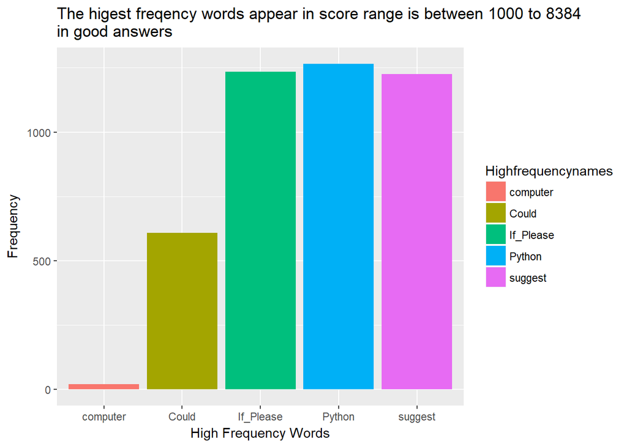

```r
newA<- tibble(id = as.integer(answers$OwnerUserId), Score = as.integer(answers$Score), Body = as.character(answers$Body))
nA<- newA %>% arrange(desc(Score))
nA <- nA %>% filter(Score >= 1000 & Score <= 8384)
Python1<- sum(str_count(nA$Body, "p|Python"))
Could <- sum(str_count(nA$Body,"y|You(?= could|are)"))
If_please <- sum(str_count(nA$Body,"^i|If|p|Please"))
Suggest<- sum(str_count(nA$Body,"suggestion|suggest|p|Print"))
comp<- sum(str_count(nA$Body,"M|mac|computer"))
plotA<- tibble(Highfrequencynames = c("Python","Could","If_Please","suggest","computer"),Freq = c(Python1,Could,If_please,Suggest,comp))
ggplot(plotA)+
  geom_col(mapping = aes(x =Highfrequencynames, y = Freq,fill = Highfrequencynames ))+
  labs(x = "High Frequency Words", y = "Frequency",title = "The higest freqency words appear in score range is between 1000 to 8384 \nin good answers")
```

In the answers part, I found the highest one is python, obviously. But then the second followed by “If.. please” and suggestions. So the good way to contribute answers is first including critical words, and using imperative mood to express their answers. In this way, readers will be more comfortable to take actions.